# **Exploratory Data Analysis of Ford GoBike Trip Data**

by Shahad Alsulami

- Introduction
- Preliminary Wrangling
- Univariate Exploration
- Bivariate Exploration
- Multivariate Exploration
- Conclusions

## **Introduction**

> The purpose of this project is to apply the skills I learned in the Data Visualization with Matplotlip and Seaborn section of the **Udacity Data Analyst Nanodegree** program

#### **Datasets Description**

```python
# Import all packages
import numpy as np
import pandas as pd
import matplotlib.pyplot as plt
import seaborn as sns
import datetime
```

## **Preliminary Wrangling**

## **1. Gathering Data**

```python
# load data
df_bike = pd.read_csv('fordgobike-tripdata.csv')
```

## **2. Assessing Data**

```python
# Display the number of rows and columns
df_bike.shape
```

```
(183412, 16)
```

```python
# Display the first 5 rows
df_bike.head()
```

|  | duration_sec | start_time | end_time | start_station_id | start_station_name | start_station_latitude | start_station_longitude | end_station_id | end_station_name | end_station_latitude | end_station_longitude | bike_id | user_type | member_birth_year | member_gender | bike_share_for_all_trip |
| --- | --- | --- | --- | --- | --- | --- | --- | --- | --- | --- | --- | --- | --- | --- | --- | --- |
| 0 | 52185 | 2019-02-28 17:32:10.1450 | 2019-03-01 08:01:55.9750 | 21.0 | Montgomery St BART Station (Market St at 2nd St) | 37.789625 | -122.400811 | 13.0 | Commercial St at Montgomery St | 37.794231 | -122.402923 | 4902 | Customer | 1984.0 | Male | No |
| 1 | 42521 | 2019-02-28 18:53:21.7890 | 2019-03-01 06:42:03.0560 | 23.0 | The Embarcadero at Steuart St | 37.791464 | -122.391034 | 81.0 | Berry St at 4th St | 37.775880 | -122.393170 | 2535 | Customer | NaN | NaN | No |
| 2 | 61854 | 2019-02-28 12:13:13.2180 | 2019-03-01 05:24:08.1460 | 86.0 | Market St at Dolores St | 37.769305 | -122.426826 | 3.0 | Powell St BART Station (Market St at 4th St) | 37.786375 | -122.404904 | 5905 | Customer | 1972.0 | Male | No |
| 3 | 36490 | 2019-02-28 17:54:26.0100 | 2019-03-01 04:02:36.8420 | 375.0 | Grove St at Masonic Ave | 37.774836 | -122.446546 | 70.0 | Central Ave at Fell St | 37.773311 | -122.444293 | 6638 | Subscriber | 1989.0 | Other | No |
| 4 | 1585 | 2019-02-28 23:54:18.5490 | 2019-03-01 00:20:44.0740 | 7.0 | Frank H Ogawa Plaza | 37.804562 | -122.271738 | 222.0 | 10th Ave at E 15th St | 37.792714 | -122.248780 | 4898 | Subscriber | 1974.0 | Male | Yes |

I will convert `duration_sec` column from seconds to minutes and rename it to `duration_min` in the data cleaning

```python
# Display a summary of the DataFrame
df_bike.info()
```

```
<class 'pandas.core.frame.DataFrame'>
RangeIndex: 183412 entries, 0 to 183411
Data columns (total 16 columns):
 #   Column                   Non-Null Count   Dtype
---  ------                   --------------   -----
 0   duration_sec             183412 non-null  int64
 1   start_time               183412 non-null  object
 2   end_time                 183412 non-null  object
 3   start_station_id         183215 non-null  float64
 4   start_station_name       183215 non-null  object
 5   start_station_latitude   183412 non-null  float64
 6   start_station_longitude  183412 non-null  float64
 7   end_station_id           183215 non-null  float64
 8   end_station_name         183215 non-null  object
 9   end_station_latitude     183412 non-null  float64
 10  end_station_longitude    183412 non-null  float64
 11  bike_id                  183412 non-null  int64
 12  user_type                183412 non-null  object
 13  member_birth_year        175147 non-null  float64
 14  member_gender            175147 non-null  object
 15  bike_share_for_all_trip  183412 non-null  object
dtypes: float64(7), int64(2), object(7)
memory usage: 22.4+ MB
```

I will convert `start_time` and `end_time` to datetime in the cleaning data

```python
# Count the number of missing values
df_bike.isna().sum()
```

```
duration_sec                  0
start_time                    0
end_time                      0
start_station_id            197
start_station_name          197
start_station_latitude        0
start_station_longitude       0
end_station_id              197
end_station_name            197
end_station_latitude          0
end_station_longitude         0
bike_id                       0
user_type                     0
member_birth_year          8265
member_gender              8265
bike_share_for_all_trip       0
dtype: int64
```

I will drop rows with missing values in `start_station_id`, `start_station_name`, `end_station_id`, and `end_station_name` and fill missing values in `member_gender` with "Unknown" in the cleaning data

## **3. Cleaning Data**

```python
# Convert duration from sec to min and rename the column
df_bike['duration_sec'] = df_bike['duration_sec'] / 60
df_bike.rename(columns={'duration_sec': 'duration_min'}, inplace=True)
```

**Test:**

```python
# Display the first 5 rows
df_bike.head()
```

|  | duration_min | start_time | end_time | start_station_id | start_station_name | start_station_latitude | start_station_longitude | end_station_id | end_station_name | end_station_latitude | end_station_longitude | bike_id | user_type | member_birth_year | member_gender | bike_share_for_all_trip |
| --- | --- | --- | --- | --- | --- | --- | --- | --- | --- | --- | --- | --- | --- | --- | --- | --- |
| 0 | 869.750000 | 2019-02-28 17:32:10.1450 | 2019-03-01 08:01:55.9750 | 21.0 | Montgomery St BART Station (Market St at 2nd St) | 37.789625 | -122.400811 | 13.0 | Commercial St at Montgomery St | 37.794231 | -122.402923 | 4902 | Customer | 1984.0 | Male | No |
| 1 | 708.683333 | 2019-02-28 18:53:21.7890 | 2019-03-01 06:42:03.0560 | 23.0 | The Embarcadero at Steuart St | 37.791464 | -122.391034 | 81.0 | Berry St at 4th St | 37.775880 | -122.393170 | 2535 | Customer | NaN | NaN | No |
| 2 | 1030.900000 | 2019-02-28 12:13:13.2180 | 2019-03-01 05:24:08.1460 | 86.0 | Market St at Dolores St | 37.769305 | -122.426826 | 3.0 | Powell St BART Station (Market St at 4th St) | 37.786375 | -122.404904 | 5905 | Customer | 1972.0 | Male | No |
| 3 | 608.166667 | 2019-02-28 17:54:26.0100 | 2019-03-01 04:02:36.8420 | 375.0 | Grove St at Masonic Ave | 37.774836 | -122.446546 | 70.0 | Central Ave at Fell St | 37.773311 | -122.444293 | 6638 | Subscriber | 1989.0 | Other | No |
| 4 | 26.416667 | 2019-02-28 23:54:18.5490 | 2019-03-01 00:20:44.0740 | 7.0 | Frank H Ogawa Plaza | 37.804562 | -122.271738 | 222.0 | 10th Ave at E 15th St | 37.792714 | -122.248780 | 4898 | Subscriber | 1974.0 | Male | Yes |

```python
# Convert start and end time to datetime
df_bike['start_time'] = pd.to_datetime(df_bike['start_time'])
df_bike['end_time'] = pd.to_datetime(df_bike['end_time'])
```

**Test:**

```python
# Validate the cleaning was successful
df_bike.info()
```

```
<class 'pandas.core.frame.DataFrame'>
RangeIndex: 183412 entries, 0 to 183411
Data columns (total 16 columns):
 #   Column                   Non-Null Count   Dtype
---  ------                   --------------   -----
 0   duration_min             183412 non-null  float64
 1   start_time               183412 non-null  datetime64[ns]
 2   end_time                 183412 non-null  datetime64[ns]
 3   start_station_id         183215 non-null  float64
 4   start_station_name       183215 non-null  object
 5   start_station_latitude   183412 non-null  float64
 6   start_station_longitude  183412 non-null  float64
 7   end_station_id           183215 non-null  float64
 8   end_station_name         183215 non-null  object
 9   end_station_latitude     183412 non-null  float64
 10  end_station_longitude    183412 non-null  float64
 11  bike_id                  183412 non-null  int64
 12  user_type                183412 non-null  object
 13  member_birth_year        175147 non-null  float64
 14  member_gender            175147 non-null  object
 15  bike_share_for_all_trip  183412 non-null  object
dtypes: datetime64[ns](2), float64(8), int64(1), object(5)
memory usage: 22.4+ MB
```

```python
# Remove rows with missing value
df_bike.dropna(subset=['start_station_id','start_station_name','end_station_id','end_station_name'], inplace=True)
```

**Test:**

```python
# Validate the cleaning was successful
df_bike[['start_station_id','start_station_name','end_station_id','end_station_name']].isna().sum()
```

```
start_station_id      0
start_station_name    0
end_station_id        0
end_station_name      0
dtype: int64
```

```python
# Fill missing values with 'Unkown'
df_bike['member_gender'] = df_bike['member_gender'].fillna('Unknown')
```

**Test:**

```python
# Validate the cleaning was successful
df_bike['member_gender'].isna().sum()
```

```
0
```

```python
# Calculate age
current_year = datetime.datetime.now().year

# Create new column
df_bike['age'] = df_bike['member_birth_year'].apply( lambda x: int(current_year - x) if pd.notna(x) else None
)
```

**Test:**

```python
# Validate the cleaning was successful
df_bike.head()
```

|  | duration_min | start_time | end_time | start_station_id | start_station_name | start_station_latitude | start_station_longitude | end_station_id | end_station_name | end_station_latitude | end_station_longitude | bike_id | user_type | member_birth_year | member_gender | bike_share_for_all_trip | age |
| --- | --- | --- | --- | --- | --- | --- | --- | --- | --- | --- | --- | --- | --- | --- | --- | --- | --- |
| 0 | 869.750000 | 2019-02-28 17:32:10.145 | 2019-03-01 08:01:55.975 | 21.0 | Montgomery St BART Station (Market St at 2nd St) | 37.789625 | -122.400811 | 13.0 | Commercial St at Montgomery St | 37.794231 | -122.402923 | 4902 | Customer | 1984.0 | Male | No | 41.0 |
| 1 | 708.683333 | 2019-02-28 18:53:21.789 | 2019-03-01 06:42:03.056 | 23.0 | The Embarcadero at Steuart St | 37.791464 | -122.391034 | 81.0 | Berry St at 4th St | 37.775880 | -122.393170 | 2535 | Customer | NaN | Unknown | No | NaN |
| 2 | 1030.900000 | 2019-02-28 12:13:13.218 | 2019-03-01 05:24:08.146 | 86.0 | Market St at Dolores St | 37.769305 | -122.426826 | 3.0 | Powell St BART Station (Market St at 4th St) | 37.786375 | -122.404904 | 5905 | Customer | 1972.0 | Male | No | 53.0 |
| 3 | 608.166667 | 2019-02-28 17:54:26.010 | 2019-03-01 04:02:36.842 | 375.0 | Grove St at Masonic Ave | 37.774836 | -122.446546 | 70.0 | Central Ave at Fell St | 37.773311 | -122.444293 | 6638 | Subscriber | 1989.0 | Other | No | 36.0 |
| 4 | 26.416667 | 2019-02-28 23:54:18.549 | 2019-03-01 00:20:44.074 | 7.0 | Frank H Ogawa Plaza | 37.804562 | -122.271738 | 222.0 | 10th Ave at E 15th St | 37.792714 | -122.248780 | 4898 | Subscriber | 1974.0 | Male | Yes | 51.0 |

### **What is the structure of your dataset?**

> `duration_min:` Duration of the trip in minutes

`start_time:` Start timestamp of the trip  
`end_time:` End timestamp of the trip  
`start_station_id:` ID of the starting station  
`end_station_id:` ID of the ending station  
`start_station_name:` Name of the starting station  
`end_station_name:` Name of the ending station  
`start_station_latitude:` Latitude of the starting station  
`end_station_latitude:` Latitude of the ending station  
`start_station_longitude:` Longitude of the starting station  
`end_station_longitude:` Longitude of the ending station  
`bike_id:` Unique ID of the bike  
`user_type:` Type of user: Customer or Subscriber  
`member_birth_year:` Birth year of the user  
`member_gender:` Gender of the user  
`age:` Age of the user

### **What is the main feature of interest in your dataset?**

> The main feature of interest is trip duration `duration_min`, I will analyze how user age, gender , and type affect trip duration and usage patterns

### **What features in the dataset do you think will help support your investigation into your feature of interest?**

> The features that will help support my investigation into trip duration are:  
> `age:` to estimate user age and explore its relation to trip duration  
> `member_gender:` to analyze differences in usage between genders  
> `user_type:` to compare ride duration between subscribers and customers

## **4.Univariate Exploration**

> In this section, I will explore
> - What is the typical duration of bike trips?
> - Which age group use the bike the most?
> - Is there gender variation in bike usage?
> - Are there more Subscribers or Customers?

### **1-Trip Duration:**

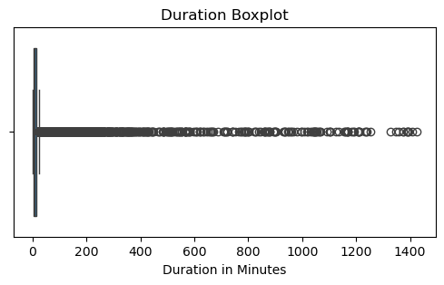

```python
# Create a box plot to show the distribution of the 'duration_min' column
duration_box = plt.figure(figsize=(6,3))
sns.boxplot(data=df_bike, x='duration_min')
plt.title('Duration Boxplot')
plt.xlabel('Duration in Minutes')
plt.show()
```

- From the boxplot, I noticed that some trips are up to 1400 minutes, which is too much for a bike, and I will remove any trip longer than 300 minutes (5 hours) to keep the analysis accurate

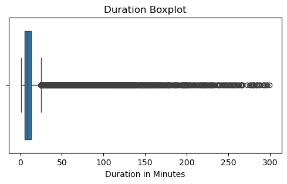

```python
# Create a box plot to show the distribution of the 'duration_min' column after remove outliers
df_duration_filtered = df_bike[df_bike['duration_min'] <= 300].copy()
duration_box2 = plt.figure(figsize=(6,3))
sns.boxplot(data=df_duration_filtered, x='duration_min')
plt.title('Duration Boxplot')
plt.xlabel('Duration in Minutes')
plt.show()
```

- I made a new dataset called **df_duration_filtered** with only trips that are 5 hours or less

### **What is the typical duration of bike trips?**

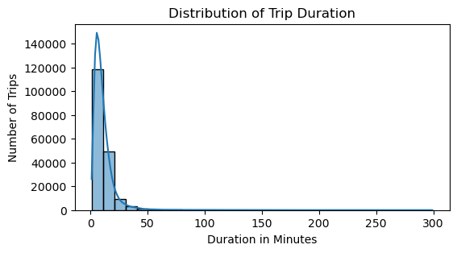

[output not shown]

```python
# Create a histogram to show the distribution of the 'duration_min' column
duration_dis = plt.figure(figsize=(6,3))
sns.histplot(data=df_duration_filtered, x='duration_min', bins=30, kde=True)
plt.title('Distribution of Trip Duration')
plt.xlabel('Duration in Minutes')
plt.ylabel('Number of Trips')
plt.show()

# Display summary statistics
df_clean['duration_min'].describe()
```

- The histogram of trip durations shows a **right-skewed** distribution
- Most bike rides last less than 13 minutes, showing it's usually used for short city rides
- Long trips are rare and not typical

### **2-Age:**

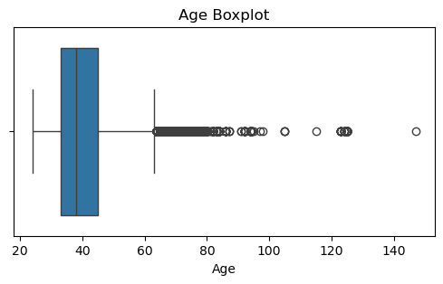

```python
# Create a box plot to show the distribution of the 'age' column
age_box = plt.figure(figsize=(6,3))
sns.boxplot(data=df_duration_filtered, x='age')
plt.title('Age Boxplot')
plt.xlabel('Age')
plt.show()
```

- From the boxplot, I noticed that there are ages over 100, and I will remove them from the dataFrame to keep the analysis accurate

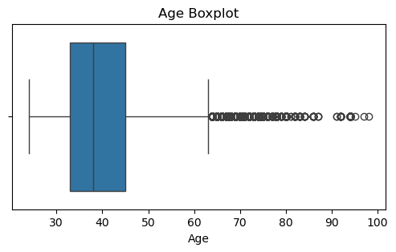

```python
# Create a box plot to show the distribution of the 'age' column after remove outliers
df_clean=df_duration_filtered[df_duration_filtered['age'] <= 100].copy()
age_box2 = plt.figure(figsize=(6,3))
sns.boxplot(data=df_clean, x='age')
plt.title('Age Boxplot')
plt.xlabel('Age')
plt.show()
```

- I made a new dataset called **df_clean** , and i will use it for all my analysis

### **Which age group use the bike the most?**

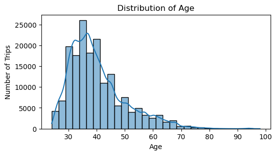

```python
# Create a histo plot to show the distribution of the 'age' column
age_dis = plt.figure(figsize=(6,3))
sns.histplot(data=df_clean, x='age', bins=30, kde=True)
plt.title('Distribution of Age')
plt.xlabel('Age')
plt.ylabel('Number of Trips')
plt.show()
```

- The Histogram shows a **right-skewed** distribution

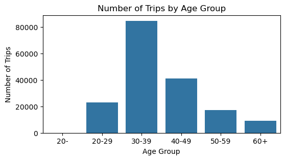

```python
# Divide ages into groups using pd.cut
df_clean['age_group'] = pd.cut(df_clean['age'],
                               bins=[0, 20, 30, 40, 50, 60, 100],
                               labels=['20-', '20-29', '30-39', '40-49', '50-59', '60+'])
# Create a count plot
age_group_bar = plt.figure(figsize=(6,3))
sns.countplot(data=df_clean, x='age_group')
plt.title('Number of Trips by Age Group')
plt.xlabel('Age Group')
plt.ylabel('Number of Trips')
plt.show()
```

- The Countplot shows that most riders are between 30-40 years old
- The Countplot shows under 20 age group is not present from the data

### **3-Gender:**

### **Is there gender variation in bike usage?**

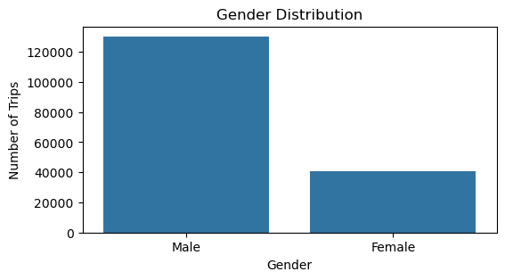

```python
# Create a count plot to show the distribution of the 'gender' column
plt.figure(figsize=(6,3))
sns.countplot(data=df_clean[(df_clean['member_gender'] != 'Unknown') & (df_clean['member_gender'] != 'Other')],
              x='member_gender',
             )
plt.title('Gender Distribution')
plt.xlabel('Gender')
plt.ylabel('Number of Trips')
plt.show()
```

- The Countplot shows that males use the bikes more than females

### **4-User Type:**

### **Are there more Subscribers or Customers?**

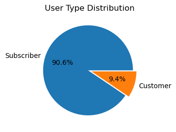

```python
# Count the number of each user type
user_counts = df_clean['user_type'].value_counts()

# Create a pie chart to show the distrهbution of user type
plt.figure(figsize=(6,3))
plt.pie(user_counts, labels=user_counts.index,autopct='%1.1f%%', explode=(0.04, 0.04)
)
plt.title('User Type Distribution')
plt.show()
```

- The pie chart shows that subscribers use the bikes more than customers

### Discuss the distribution(s) of your variable(s) of interest. Were there any unusual points? Did you need to perform any transformations?

> The distribution of trip duration showed some outliers, with some trips lasting over 1400 minutes, which is unrealistic for bike usage. I considered any trip longer than 300 minutes (5 hours) as an outlier and excluded it from the data

### Of the features you investigated, were there any unusual distributions? Did you perform any operations on the data to tidy, adjust, or change the form of the data? If so, why did you do this?

> Yes, the age variable had some unrealistic values over 100 years old, so I removed them to improve data quality. I also removed the outliers in trip duration as mentioned before

## **5.Bivariate Exploration**

> In this section, I will explore
> - Which age group tends to have the longest trips?
> - Which gender tends to take longer bike trips?
> - Which user type tends to take longer bike trips?
> - On which weekdays users take the longest bike trips?

### **1.Trip Duration vs. Age:**

### **Which age group tends to have the longest trips?**

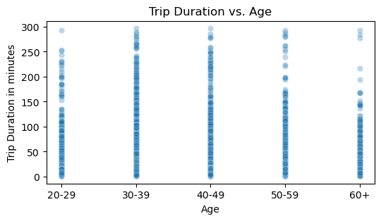

```python
# Create a scatter plot to show the relationship between duration and age
plt.figure(figsize=(6,3))
sns.scatterplot(data=df_clean, x='age_group', y='duration_min', alpha=0.3)
plt.title('Trip Duration vs. Age')
plt.xlabel('Age')
plt.ylabel('Trip Duration in minutes')
plt.show()
```

### **2.Trip Duration vs. Gender:**

### **Which gender tends to take longer bike trips?**

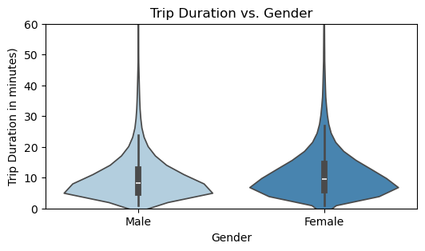

```python
# Create a violin plot to show the relationship between duration and gender
plt.figure(figsize=(6,3))
sns.violinplot(data=df_clean[(df_clean['member_gender'] != 'Unknown') & (df_clean['member_gender'] != 'Other')],
               x='member_gender', y='duration_min', hue='member_gender', palette="Blues")
plt.ylim(0, 60)
plt.title('Trip Duration vs. Gender')
plt.xlabel('Gender')
plt.ylabel('Trip Duration in minutes)')
plt.show()
```

- Most trips are short for both genders
- There is no significant difference in long trip durations between genders
- Males show a higher density in the short trip duration range compared to females

### **3.Trip Duration vs. User Type:**

### **Which user type tends to take longer bike trips?**

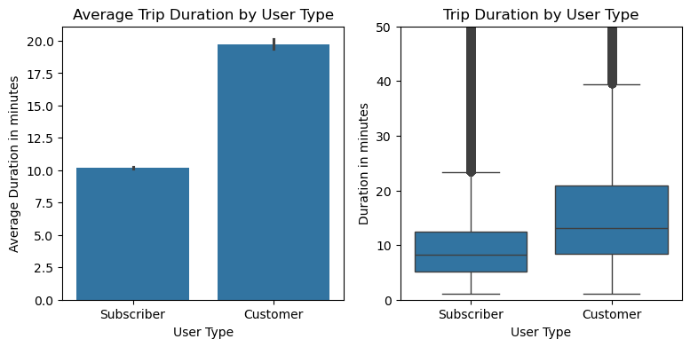

```python
# Set figure size
plt.figure(figsize=(9, 4))

# Create a bar plot to show the average trip duration by user type
plt.subplot(1, 2, 1)
sns.barplot(data=df_clean, x='user_type', y='duration_min')
plt.title('Average Trip Duration by User Type')
plt.xlabel('User Type')
plt.ylabel('Average Duration in minutes')

# Create a box plot to show the distribution trip duration by user type
plt.subplot(1, 2, 2)
sns.boxplot(data=df_clean, x='user_type', y='duration_min')
plt.title('Trip Duration by User Type')
plt.xlabel('User Type')
plt.ylabel('Duration in minutes')
plt.ylim(0, 50)
plt.show()
```

- Customers tend to take longer trips, as their average trip duration is higher than that of subscribers
- Subscribers usually take shorter trips

### **4.Trip Duration vs. Day of Week:**

### **On which weekdays users take the longest bike trips?**

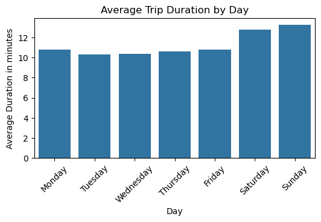

```python
# Extract day names from 'start_time' and add as a new column 'day_of_week'
df_clean['day_of_week'] = df_clean['start_time'].dt.day_name()

# Define the order of days
order_days = ['Monday', 'Tuesday', 'Wednesday', 'Thursday', 'Friday', 'Saturday', 'Sunday']

# Create a bar plot to show the average trip duration by weekdays
plt.figure(figsize=(6,3))
sns.barplot(data=df_clean, x='day_of_week', y='duration_min', order=order_days, errorbar=None)
plt.title('Average Trip Duration by Day')
plt.xlabel('Day')
plt.ylabel('Average Duration in minutes')
plt.xticks(rotation=45)
plt.show()
```

- The longest trips happen on **Saturday** and **Sunday**, This might be because people have more free time on the weekends
- On weekdays, trips are generally shorter

### Did you observe any interesting relationships between the other features (not the main feature(s) of interest)?

> I focused on how the main feature (trip duration) relates to other variables. I did not explore relationships between other features without involving trip duration

## **6.Multivariate Exploration**

> In this section, I will explore
> - How does trip duration vary by age and user type?
> - Does trip duration differ between males and females based on user type?
> - How do day of the week and gender affect trip duration?

### **1. Trip Duration vs. Age vs. User Type:**

### **How does trip duration vary by age and user type?**

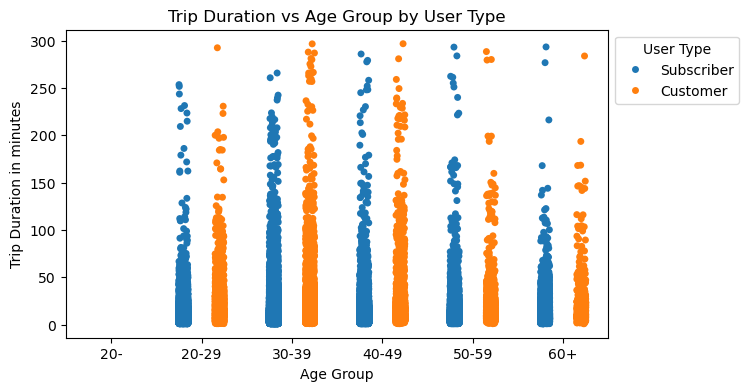

```python
# Creae a strip plot to show the relationship between age and trip duration by user type

plt.figure(figsize=(7,4))
sns.stripplot(
    data=df_clean,
    x='age_group',
    y='duration_min',
    hue='user_type',
    dodge=True,
)
plt.title('Trip Duration vs Age Group by User Type')
plt.xlabel('Age Group')
plt.ylabel('Trip Duration in minutes')
plt.legend(title='User Type', bbox_to_anchor=(1, 1))
plt.show()
```

### **2. Trip Duration vs. Gender vs. User Type:**

### **Does trip duration differ between males and females based on user type?**

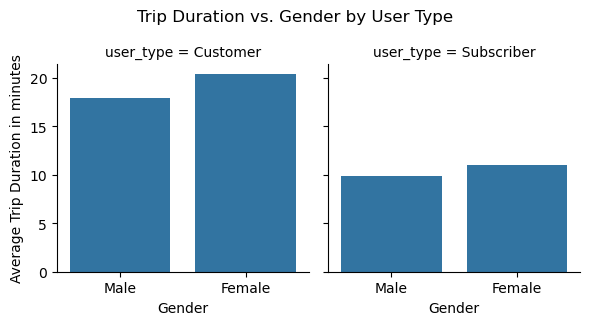

```python
# Calculate average trip duration by user type and gender
avg_duration = df_clean.groupby(['user_type', 'member_gender'])['duration_min'].mean().reset_index()

# Use FacetGrid to create separate bar plots
facet_grid = sns.FacetGrid(avg_duration, col="user_type", height=3)
facet_grid.map_dataframe(sns.barplot, x='member_gender', y='duration_min', order=['Male', 'Female'])
facet_grid.set_axis_labels("Gender", "Average Trip Duration in minutes")
facet_grid.fig.suptitle("Trip Duration vs. Gender by User Type", y=1.07)
plt.show()
```

**Customer**

- Average trip duration for females is higher than males
- The difference is not very large

**Subscriber**

- Females also have a slightly higher average trip duration than males
- The difference here is very small

**Overall**

- In both groups, females tend to have slightly longer trip durations
- The difference is not very significant

### **How do day of the week and gender affect trip duration?**

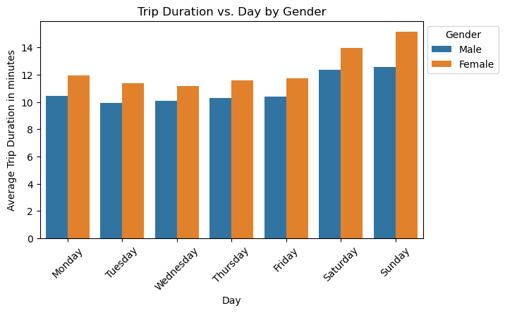

```python
# Define the order of days
order_days = ['Monday', 'Tuesday', 'Wednesday', 'Thursday', 'Friday', 'Saturday', 'Sunday']

# Create a bar plot to show the relationship between average trip duration and weekdays by gender
plt.figure(figsize=(7,4))
sns.barplot(data=df_clean[(df_clean['member_gender'] != 'Unknown') & (df_clean['member_gender'] != 'Other')],
            x='day_of_week', y='duration_min', hue='member_gender', order=order_days, errorbar=None,),
plt.xlabel('Day')
plt.ylabel('Average Trip Duration in minutes')
plt.title('Trip Duration vs. Day by Gender')
plt.xticks(rotation=45)
plt.legend(title='Gender', bbox_to_anchor=(1, 1))
plt.show()
```

- The longest trips happen on Saturday and Sunday for both genders
- Across all days, females tend to have longer trip durations than males
- On weekdays, trips are generally shorter for everyone

```python
# Save the new dataset
df_clean.to_csv('cleanforsdgobike.csv', index=False)
```

### Were there any interesting or surprising interactions between features?

> I focused on how the main feature (trip duration) relates to other variables. I did not explore relationships between other features without involving trip duration